# Compare COI Primers

Mary Fisher

1/26/2022

# Description

The first sequencing lane was designed to answer three questions:

1. Which primer(s) do we want to use for the remainder of the (1) Salish Sea Green crab, (2) Willapa Bay Green crab, and (3) Dungeness crab instars? Factors to consider: amplification of predator DNA, presence of expected prey / prey of particular interest
2. Are we getting usable data from the 2018 Salish Sea Green crab samples, which are subsamples of the 95% etOH in which dissected stomachs were stored?
3. Are there any major signals of contamination from the SEFS lab (not particularly relevant anymore)

# Set up

This script requires the following packages:

```r
library(here)
library(tidyverse)
library(magrittr)
library(cowplot)
```

User directories

```r
indir_blast  <- 'test-lane-1/data/blast'
indir_asv    <- 'test-lane-1/data/dada2'
indir_meta   <- 'test-lane-1/data/cutadapt'
outdir       <- 'test-lane-1/results'
```

What are the suffixes of the processed blast file with taxonomy from script 6?

```r
# hashes with unique staxids
suffix1 <- 'blast_uniqueIDs_taxonomy.csv'

# hashes with multiple IDs, that required the LCA function
suffix2 <- 'blast_multipleIDs_taxonomy.csv'
```

# Question 1: Primer Comparison

**Which primer(s) do we want to use for the remainder of the (1) Salish Sea Green crab, (2) Willapa Bay Green crab, and (3) Dungeness crab instars?**

## Data

To answer this question, we need both the ASV table and the Blast taxonomy.

```r
asv.b   <- read_csv(here(indir_asv,'BF3', 'merged_ASV_table.csv'))
asv.l   <- read_csv(here(indir_asv,'Leray', 'merged_ASV_table.csv'))
asv.lxt <- read_csv(here(indir_asv,'LerayXT', 'merged_ASV_table.csv'))
```

Note that the processed blast taxonomy files have results from forward-only, reverse-only, and merged reads. for this comparison, let’s focus only on merged reads.

```r
tax_key.b <- read_csv(here(indir_blast, paste0("lane1_bf3_",suffix2))) %>%
  rename("Hash"=representative)
tax_key.b %<>%  bind_rows(read_csv(here(indir_blast, paste0("lane1_bf3_",suffix1))) %>%
              rename("Hash"=qseqid) %>%
                mutate(taxID="unique", score="unique") %>%
              dplyr::select(all_of(colnames(tax_key.b)))) %>%
  filter(dataset=="merged")

tax_key.l <- read_csv(here(indir_blast, paste0("lane1_leray_",suffix2))) %>%
  rename("Hash"=representative)
tax_key.l %<>%  bind_rows(read_csv(here(indir_blast, paste0("lane1_leray_",suffix1))) %>%
              rename("Hash"=qseqid) %>%
                mutate(taxID="unique", score="unique") %>%
              dplyr::select(all_of(colnames(tax_key.l)))) %>%
  filter(dataset=="merged")

tax_key.lxt <- read_csv(here(indir_blast, paste0("lane1_lerayxt_",suffix2))) %>%
  rename("Hash"=representative)
tax_key.lxt %<>%  bind_rows(read_csv(here(indir_blast, paste0("lane1_lerayxt_",suffix1))) %>%
              rename("Hash"=qseqid) %>%
                mutate(taxID="unique", score="unique") %>%
              dplyr::select(all_of(colnames(tax_key.lxt)))) %>%
  filter(dataset=="merged")
```

Connect the taxonomy to the hashes in the ASV tables.

```r
bdat   <- left_join(asv.b, tax_key.b,by="Hash")
ldat   <- left_join(asv.l, tax_key.l,by="Hash")
lxtdat <- left_join(asv.lxt, tax_key.lxt,by="Hash")
```

To differentiate between crab species and sampling groups, read in the sequencing metadata and connect to the `Sample_name` (actually just an ID number) in the ASV table.

```r
marker    <- c("BF3", "Leray", "LerayXT")

for(m in marker){
  metadat <- read_csv(here(indir_meta, m, paste0('cutadapt_output_metadata_',m,'.csv')))

  metadat %<>% dplyr::select(Sample_name, file1) %>%
  # from the file name, get the sample ID
  mutate(SampleID=str_remove(file1,"_L001_R1_001.fastq.fastq"))
  if(m!="LerayXT"){
    metadat %<>% mutate(SampleID=str_remove(SampleID,paste0("Locus_",m,"_",m,"_")))
  } else{
    metadat %<>% mutate(SampleID=str_remove(SampleID,paste0("Locus_",m,"_LXT_")))
  }
  metadat %<>% mutate(SampleID=ifelse(Sample_name >= 10, str_sub(SampleID,start=1, end=-5),
                                      str_sub(SampleID,start=1, end=-4))) %>%
    # from the sample ID, get the site, crab ID, and replicate (tech)
    mutate(site=ifelse(SampleID %in% c("Kangaroo","PCRNegative","SpeedVacNegative"), "Control",
                       str_sub(SampleID, start=1,end=4))) %>%
    mutate(site=ifelse(site!="WASS",site,ifelse(grepl("2020",SampleID),"WASS 2020", "WASS 2018"))) %>%
    separate(col=SampleID, into=c("crab","tech"), sep=-1,remove=FALSE) %>%
    mutate(tech=tolower(tech)) %>%
    dplyr::select(-file1)

  if(m=="BF3"){
    # clean up the extra tech replicate I have for one of my crabs.
    metadat[which(metadat$SampleID=="WASS_2020_190a_25uL"),"crab"] <- "WASS_2020_190"
    metadat[which(metadat$SampleID=="WASS_2020_190a_25uL"),"tech"] <- "d"
    bdat <- left_join(bdat,metadat,by="Sample_name")
  } else if(m=="Leray"){
    ldat <- left_join(ldat,metadat,by="Sample_name")
  } else{
    lxtdat <- left_join(lxtdat,metadat,by="Sample_name")
  }

}
```

Finally, create one giant data frame. We can do this because there is a column `Marker` that specifies the primer.

```r
all_dat <- bind_rows(bdat,ldat,lxtdat)
```

## Hash similarity

First, let’s make sure the hashes are all the same length.

```r
hash.length <- list(bf3=nchar(bdat$Hash),
                    leray=nchar(ldat$Hash),
                    lxt=nchar(lxtdat$Hash))
unique(hash.length[[1]])==unique(hash.length[[2]])
```

```
## [1] TRUE
```

```r
unique(hash.length[[1]])==unique(hash.length[[3]])
```

```
## [1] TRUE
```

```r
unique(hash.length[[2]])==unique(hash.length[[3]])
```

```
## [1] TRUE
```

What proportion of all hashes are shared between primers?

```r
b.l.share   <- intersect(bdat$Hash, ldat$Hash);   length(b.l.share) / length(unique(c(ldat$Hash, bdat$Hash)))
```

```
## [1] 0
```

```r
b.lxt.share <- intersect(bdat$Hash, lxtdat$Hash); length(b.lxt.share) / length(unique(c(bdat$Hash, lxtdat$Hash)))
```

```
## [1] 0
```

```r
l.lxt.share <- intersect(ldat$Hash, lxtdat$Hash); length(l.lxt.share) / length(unique(c(ldat$Hash, lxtdat$Hash)))
```

```
## [1] 0.1718494
```

Just realizing now that since BF3 and Leray/LerayXT are different lengths, obviously the merged hashes won’t be shared…

### Leray v LerayXT

Diving deeper into the comparisons between Leray and LerayXT, let’s find proportion of hashes shared per sample, and resulting proportion of reads from shared hashes.

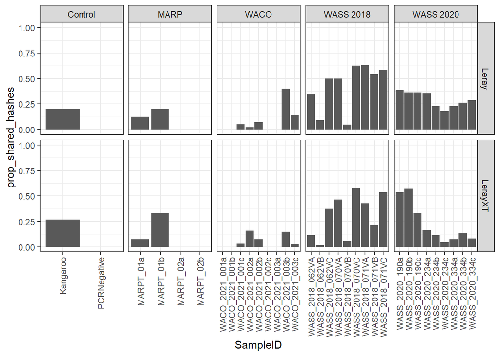

```r
l.lxt.share <- all_dat %>%
  filter(Locus %in% c("Leray","LerayXT")) %>%
  dplyr::select(SampleID,Locus,Hash) %>%
  distinct() %>%
  pivot_wider(names_from=Locus, values_from=Hash) %>%
  mutate(shared_hashes=map2(Leray,LerayXT, ~intersect(.x,.y))) %>%
  mutate(n_shared_hashes = lengths(shared_hashes))
```

## Missing Taxonomy

Which primers had the most reads that couldn’t be assigned taxonomy? **BF3**

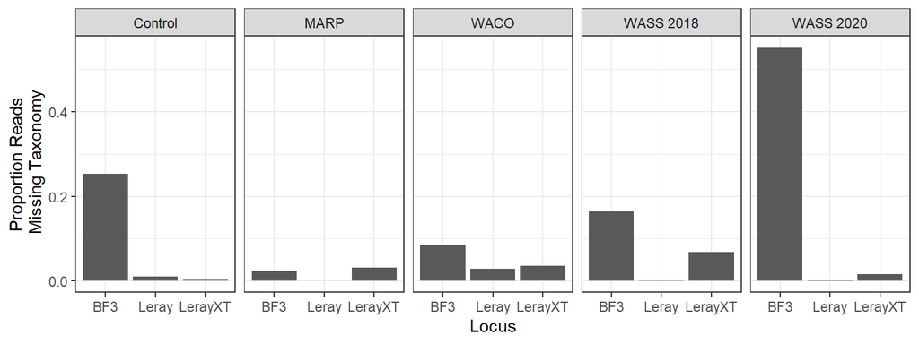

```r
all_dat2 <- filter(all_dat, !is.na(rank))
```

## Non-Target DNA

Which primers amplified the most bacterial / amoeba DNA? **BF3**

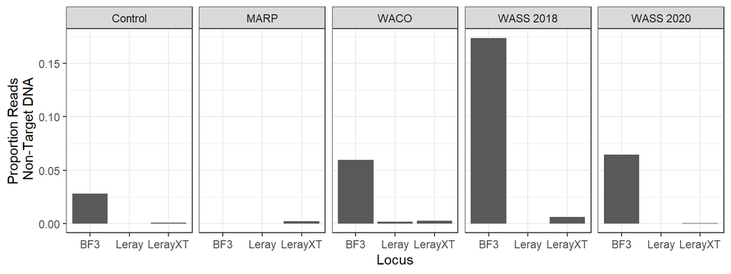

```r
all_dat3 <- all_dat2 %>% filter(!(phylum %in% c(nontarget_taxa))) %>%
  filter(class!="Mammalia")
```

Take a quick look at the controls…

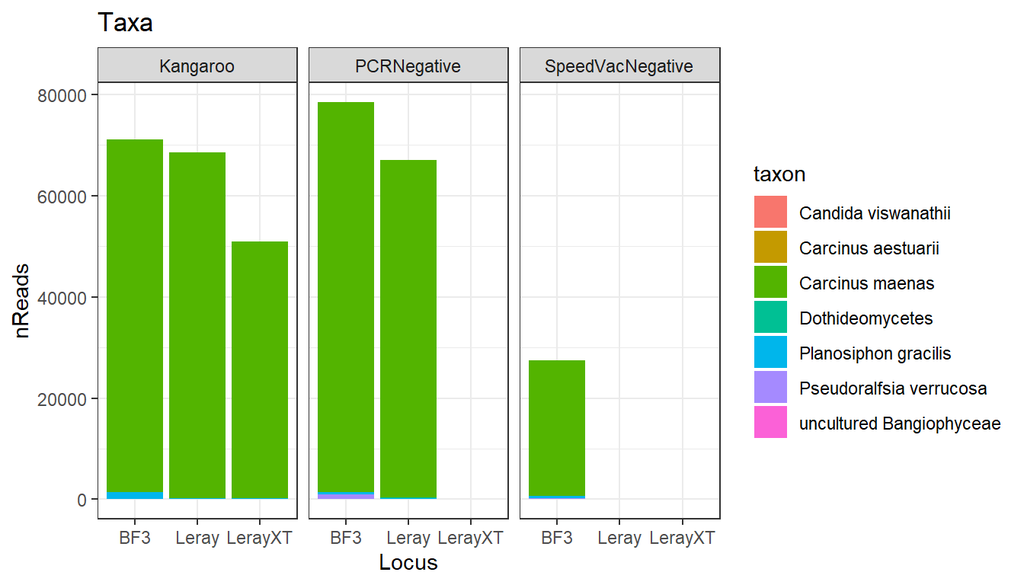

Non-bacterial species in the negative control:

- *Planosiphon gracilis*, a brown algae
- *Bangiophyceae* (class; phylum=Rhodophyta), a red algae
- *Dothideomycetes*, a fungus
- *Candida viswanathii*, a yeast

## Predator DNA

### EGC

Get only the Green Crab samples, and ignore hashes with missing taxonomic information.

```
## [1] "WACO_2021_001"  "WACO_2021_002"  "WACO_2021_003"  "WASS_2018_062V"
## [5] "WASS_2018_070V" "WASS_2018_071V" "WASS_2020_190"  "WASS_2020_234"
## [9] "WASS_2020_334"
```

Which primer amplified the least Green Crab DNA? **LerayXT**

The most Green Crab DNA? **BF3** for WASS 2020 and WASS 2018, and **Leray** otherwise.

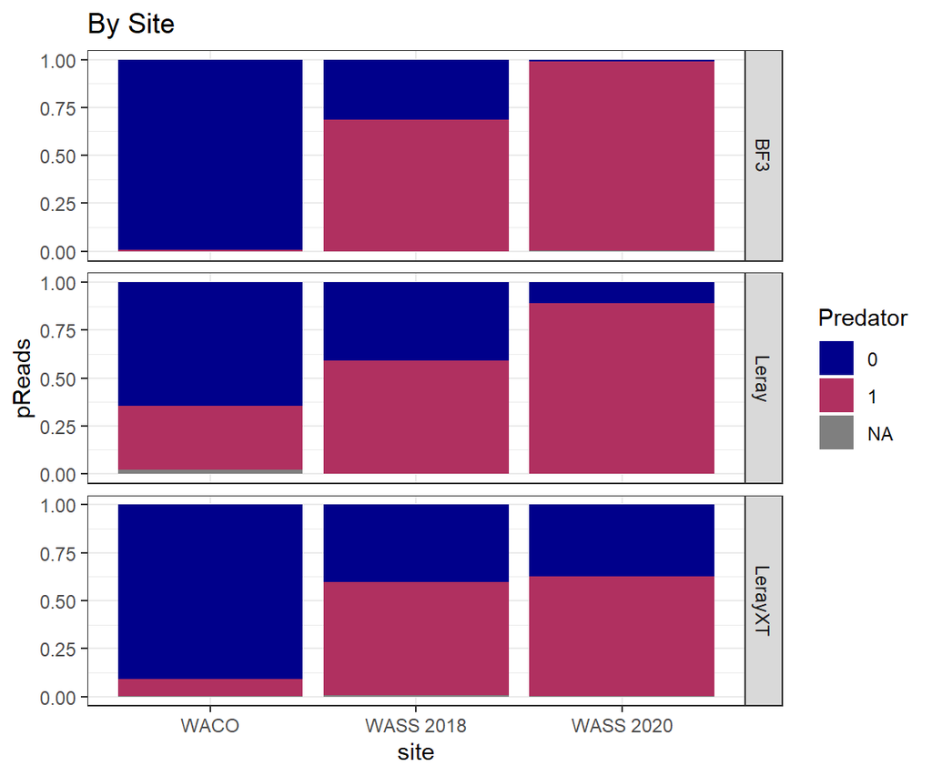

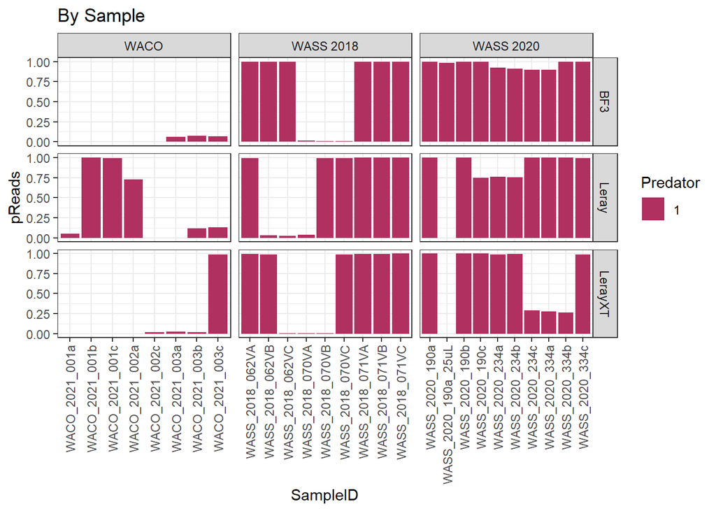

```r
egc_dat2 <- filter(all_dat3, site %in% c("WACO","WASS 2018","WASS 2020")) %>%
  mutate(Predator=ifelse(taxon == "Carcinus maenas" | taxon == "Carcinus aestuarii" |
                           genus == "Carcinus",1,0)) %>%
  filter(Predator==0 | is.na(Predator))
```

### Dungies

Get only the Dungy samples, and ignore hashes with missing taxonomic information.

```
## [1] "MARPT_01" "MARPT_02"
```

Which primer amplified the least Dungy DNA?

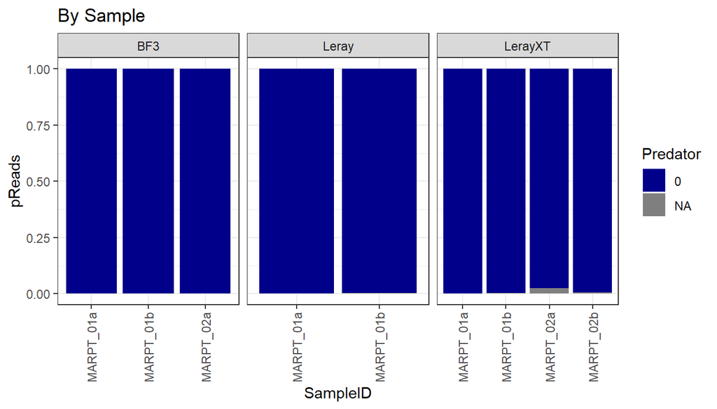

A better question: which primer amplified the least green crab DNA in the Dungy samples? **LerayXT**

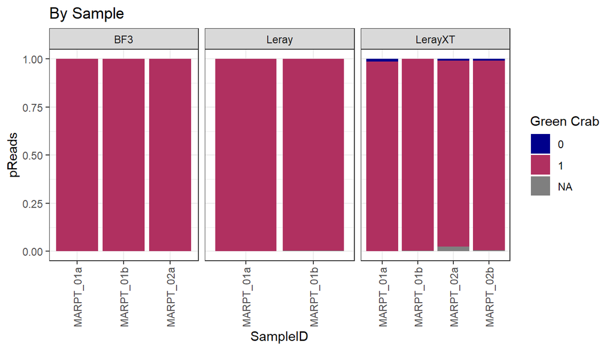

```r
dungy_dat2 <- dungy_dat %>%
  mutate(EGC=ifelse(taxon == "Carcinus maenas" | taxon == "Carcinus aestuarii" |
                           genus == "Carcinus",1,0)) %>%
  filter(EGC==0  | is.na(EGC))
```

## Prey Composition: diversity

### EGC

**How did diversity of phyla / taxa (family/genus/species) differ between primers?**

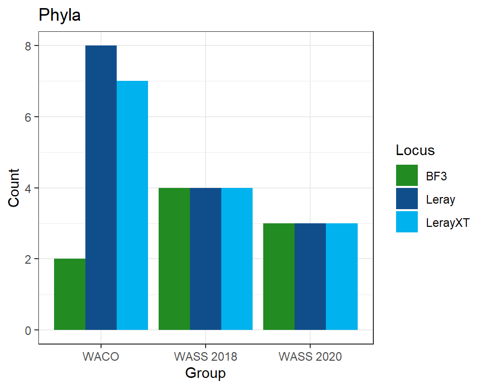

Unique phyla: Arthropoda, Mollusca, NA, Bacillariophyta, Cnidaria, Chlorophyta, Rhodophyta, Annelida, Ascomycota, Porifera, Tubulinea, Rotifera

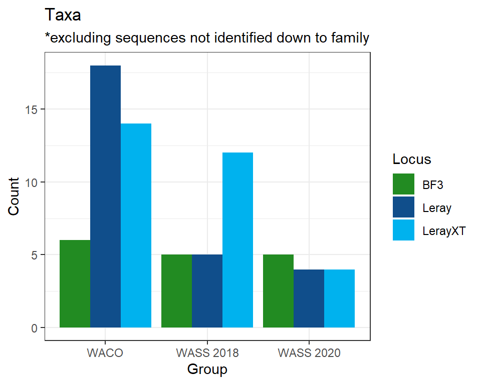

### Dungies

**How did diversity of phyla / taxa (family/genus/species) differ between primers?**

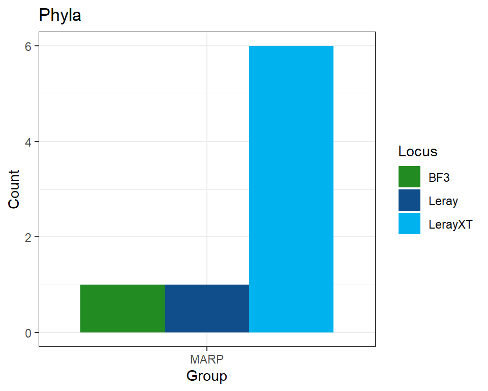

Unique phyla: NA, Arthropoda, Rotifera, Ascomycota, Rhodophyta, Annelida

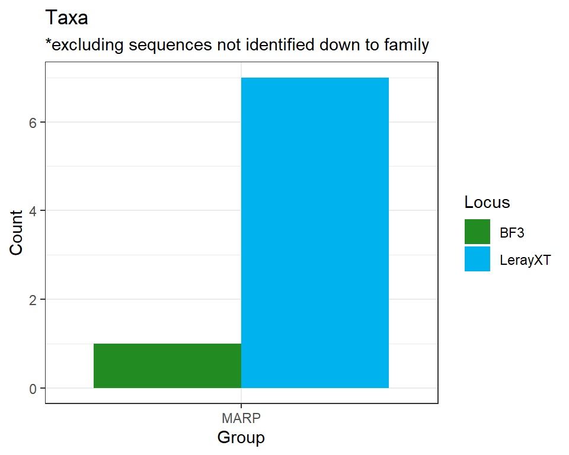

## Prey Composition: specificity

### EGC: Overview

**Which primer was able to detect the most ASVs down to the species level?**

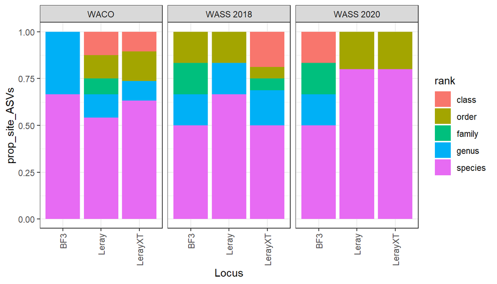

**For Arthropods, Molluscs, and Worms, which primer was able to detect the most ASVs down to the species level?** it varies by group and phylum. BF3 did best with arthropods and molluscs, but it didn’t pick up annelids and did worse than LerayXT in the WASS 2018 samples.

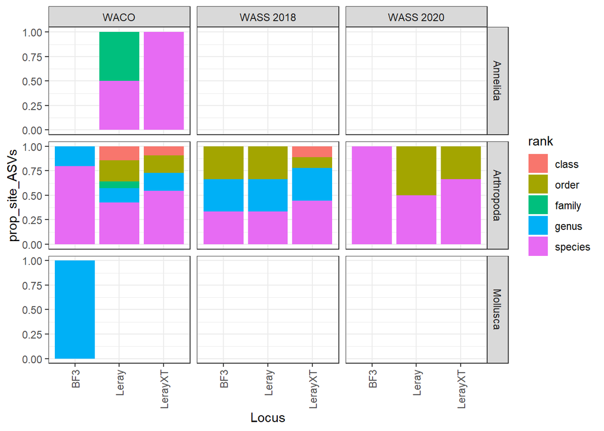

**What taxa (family/genus/species) were captured by only 1-2 primers?**

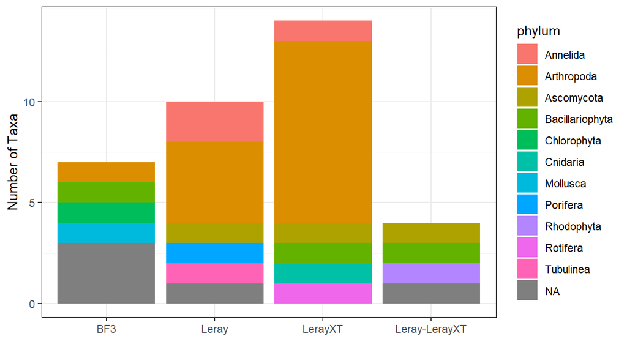

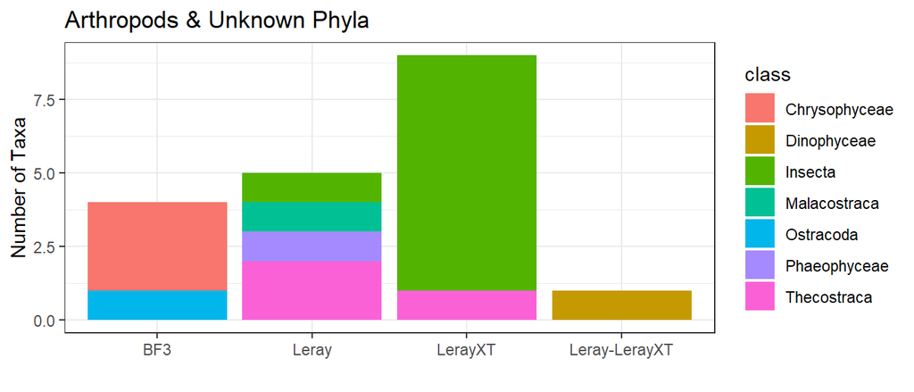

BF3 is picking up ostracods and a type of microscopic algae; Leray/LerayXT are picking up insects, barnacles (Leray down to species, LerayXT just *Balanus*); Leray is picking up some non-specific *malacostraca*… *Note - Dinophyceae >> Syndiniales >> Hematodinium are dinoflagellates that are internal parasites of crustaceans.*

### Dungy: Overview

**Which primer was able to detect the most ASVs down to the species level?**

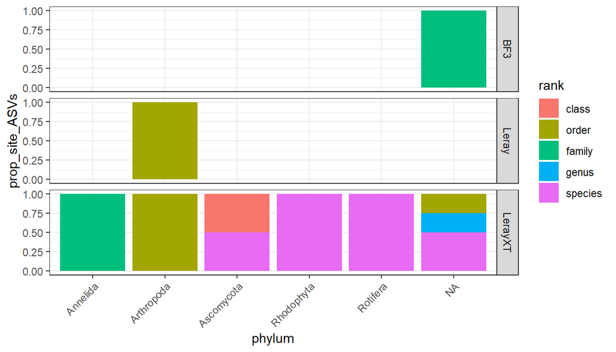

### EGC

Species of interest:

**1.** *Cancer (Metacarcinus) magister*

```
## # A tibble: 10 x 4
## # Groups:   SampleID, site [5]
##    site  SampleID       Locus   pReads
##    <chr> <chr>          <chr>    <dbl>
##  1 WACO  WACO_2021_001b BF3      0.979
##  2 WACO  WACO_2021_001b LerayXT  0.992
##  3 WACO  WACO_2021_001c BF3      0.962
##  4 WACO  WACO_2021_001c LerayXT  0.988
##  5 WACO  WACO_2021_002a Leray    0.229
##  6 WACO  WACO_2021_002a LerayXT  0.991
##  7 WACO  WACO_2021_002a BF3      1.00
##  8 WACO  WACO_2021_002b Leray    0.767
##  9 WACO  WACO_2021_002b LerayXT  0.989
## 10 WACO  WACO_2021_002c Leray    0.869
```

**2.** *Bivalvia*– most important is *Ruditapes philippinarium* (Manila clam)

```
## # A tibble: 1 x 6
## # Groups:   SampleID, site, Locus, taxon [1]
##   site  SampleID       Locus taxon rank    pReads
##   <chr> <chr>          <chr> <chr> <chr>    <dbl>
## 1 WACO  WACO_2021_001b BF3   Mya   genus 0.000216
```

What about in the forward reads?

```
## # A tibble: 7 x 6
## # Groups:   SampleID, site, Locus, taxon [7]
##   site      SampleID       Locus taxon                   rank      pReads
##   <chr>     <chr>          <chr> <chr>                   <chr>      <dbl>
## 1 WACO      WACO_2021_001b BF3   Mya                     genus   0.000236
## 2 WACO      WACO_2021_003a BF3   Mya arenaria            species 0.000459
## 3 WACO      WACO_2021_003c BF3   Mya                     genus   0.000238
## 4 WACO      WACO_2021_003c BF3   Ruditapes               genus   0.000238
## 5 WASS 2020 WASS_2020_234a Leray Ruditapes philippinarum species 0.000160
## 6 WASS 2020 WASS_2020_234b Leray Limecola                genus   0.000201
## 7 WASS 2020 WASS_2020_234b Leray Tellinidae              family  0.000201
```

# Question 2: WASS 2018 Vial Samples

**Are we getting usable data from the 2018 Salish Sea Green crab samples, which are subsamples of the 95% etOH in which dissected stomachs were stored?**

## Read Depths

Are the read depths from the 2018 samples noticeably different from the 2020 / 2021 samples? **Yes.**

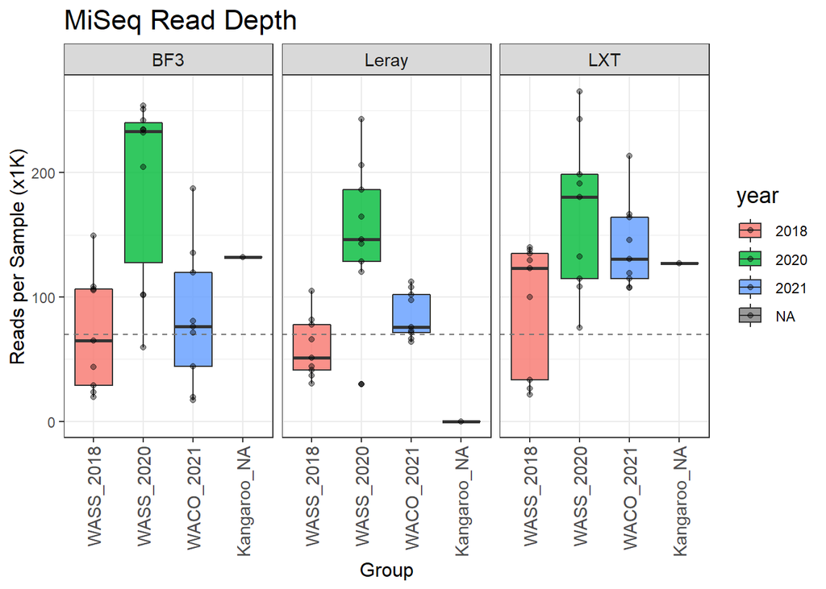

## Missing Taxonomy & Non-Target DNA

Do the 2018 samples have a higher proportion of any of the following, compared to the 2020/2021 samples?

1. missing taxonomy (**not consistently**),
2. non-target bacterial or amoeba DNA (**YES for BF3**)
3. predator DNA (**on par or less than WASS 2020**)

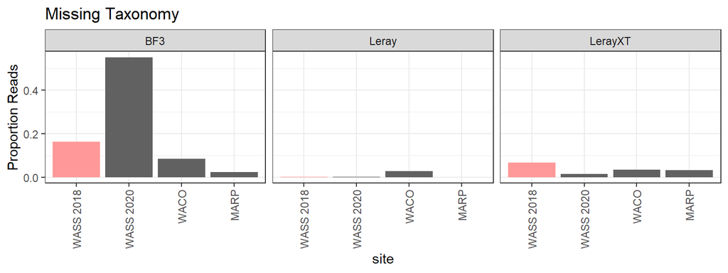

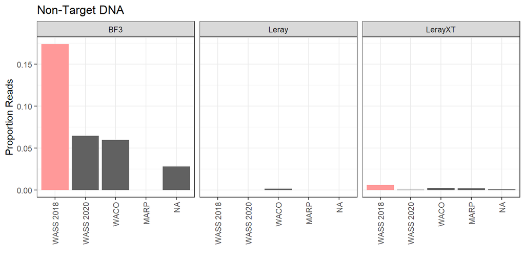

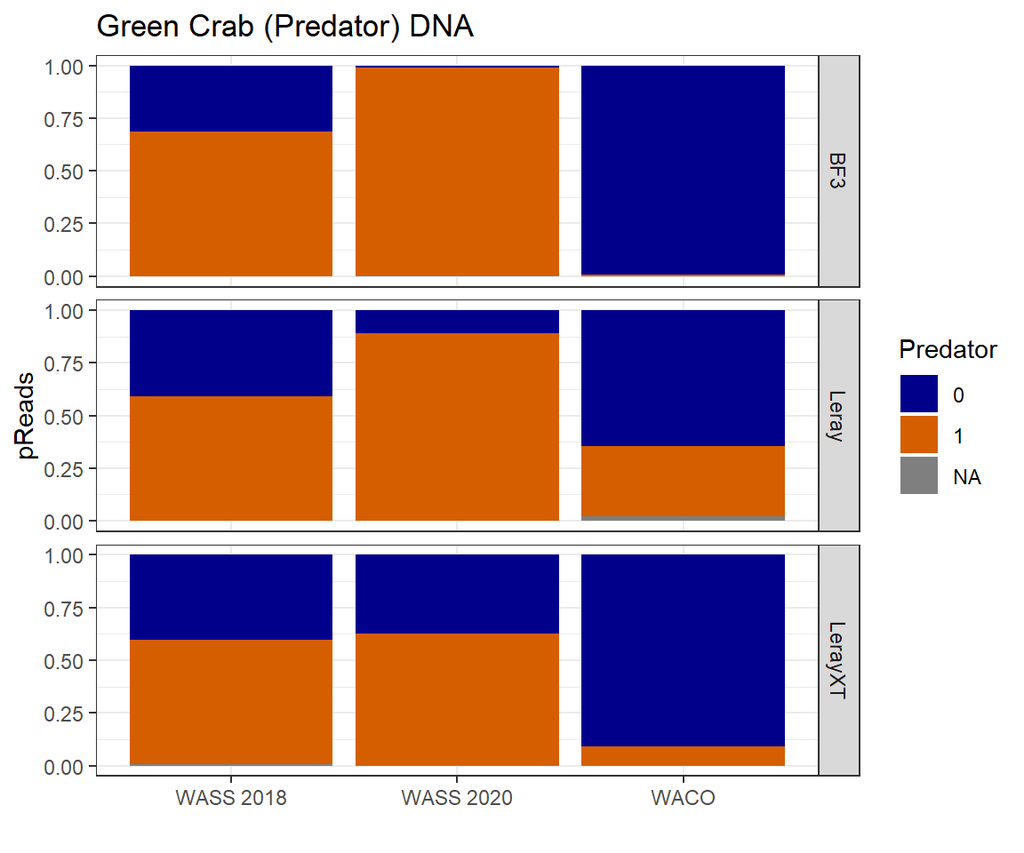

## Specificity

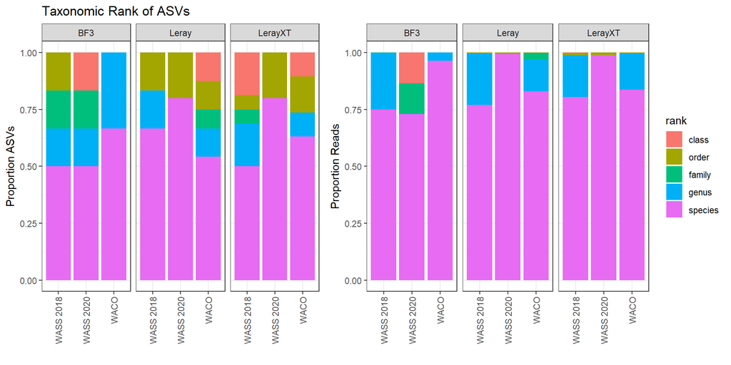

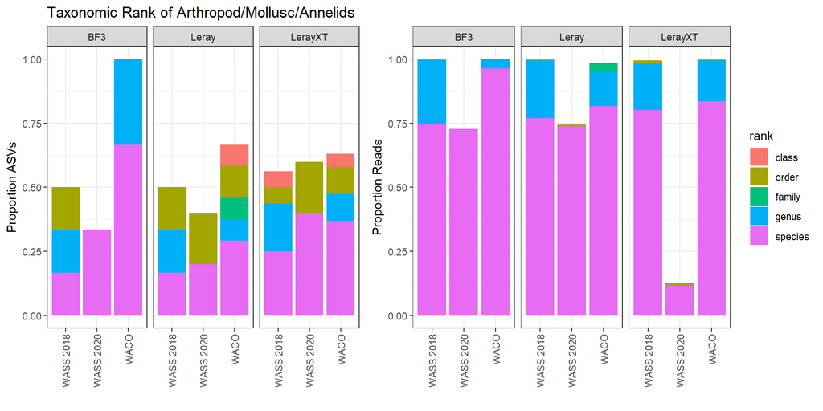

## Species of interest

**Are there any particular species that show up in the WASS 2020 samples that don’t show up in the WASS 2018 samples?**

```
## # A tibble: 8 x 4
##   phylum      taxon                    rank    sites
##   <chr>       <chr>                    <chr>   <chr>
## 1 Arthropoda  Cyprideis torosa         species WASS 2020
## 2 Arthropoda  Euglossa igniventris     species WASS 2020
## 3 Chlorophyta Chlorellaceae            family  WASS 2020
## 4 Rhodophyta  uncultured Bangiophyceae species WASS 2020
## 5 <NA>        Dinobryon                genus   WASS 2020
## 6 <NA>        Dinobryon divergens      species WASS 2020
## 7 <NA>        Hematodinium sp.         species WASS 2020
## 8 <NA>        Planosiphon gracilis     species WASS 2020
```

So primarily a bee, *Euglossia*, and an ostracod (*Cyprideis*). But WASS 2018 taxonomic output does have a bee genus, and some other insect taxonomic hits.